# Estimating and visualizing an LDA topic model

24 April 2018

This document gives some examples of how to estimate and evaluate LDA in `R`. For theses example, you’ll use the (English) speeches of EP group leaders that are part of the [EUSpeech](https://dataverse.harvard.edu/dataverse/euspeech) dataset. NB: Use setwd() to set the working directory to the folder that contains English speeches in the file speeches_ep.csv. You will also need to download the `topicmodels` library using the `install.packages()` function:

```r
Sys.setlocale(locale = "en_US.UTF-8")
```

```
## [1] "en_US.UTF-8/en_US.UTF-8/en_US.UTF-8/C/en_US.UTF-8/C"
```

```r
#load libraries
library(dplyr)
library(readtext)
library(stringr)
library(topicmodels)
library(quanteda)
library(ggplot2)

#read in the EP speeches
speeches <- readtext("speeches_ep.csv", text_field = "text", encoding = "UTF-8")

#let's do a bit of manual cleaning to remove some boiler plate terms
speeches$text <- str_replace_all(speeches$text, "ladies and gentlemen", " ")
speeches$text <- str_replace_all(speeches$text, "President", " ")
speeches$text <- str_replace_all(speeches$text, "Mr", " ")
speeches$text <- str_replace_all(speeches$text, "Council", " ")
speeches$text <- str_replace_all(speeches$text, "Commission", " ")

#concatenate the speeches
speeches <- speeches %>%
  group_by(speaker) %>%
  summarise(text = paste(text, collapse = " ")) %>%
  ungroup()

#create corpus object
speeches <- corpus(speeches)

#create a dfm
speeches.dfm <- dfm(speeches, stem = TRUE, remove=stopwords("english"), remove_punct=TRUE, ngrams = 1,  remove_numbers = TRUE)

#include only thoses features that occur in at least 5 documents
speeches.dfm <- dfm_trim(speeches.dfm, min_docfreq = 5)
```

## Estimating an LDA topic model

```r
#convert the speeches dfm to a format that can be read in by the topicmodels library
speeches.lda.dfm <- convert(speeches.dfm, to = "topicmodels")

#set the seed to make the results replicable, since topic models are probabilistic
set.seed(2)

#estimate two topic models, one with 5 topics and one with 10 topics. This may take a few minutes, depending on your system
#Gibbs refers to the Gibbs sampler, a Bayesian approach to obtaining parameter values
#k refers to the number of topics to be estimated; this is a parameter determined by the researcher
speeches.lda.5 <- LDA(speeches.lda.dfm, method = "Gibbs", k = 5)

speeches.lda.10 <- LDA(speeches.lda.dfm, method = "Gibbs", k = 10)
```

Take a look at the output of the topic model with 5 topics. For example, we can take a look at the 10 highest-loading terms for each of k topics.

```r
terms(speeches.lda.5, 10)
```

```
##       Topic 1   Topic 2      Topic 3    Topic 4    Topic 5
##  [1,] "eu"      "also"       "peopl"    "european" "european"
##  [2,] "report"  "like"       "european" "europ"    "need"
##  [3,] "countri" "european"   "want"     "must"     "think"
##  [4,] "vote"    "parliament" "eu"       "state"    "can"
##  [5,] "peopl"   "howev"      "europ"    "group"    "union"
##  [6,] "import"  "want"       "now"      "us"       "crisi"
##  [7,] "mani"    "europ"      "us"       "member"   "say"
##  [8,] "right"   "social"     "say"      "polit"    "let"
##  [9,] "union"   "say"        "go"       "treati"   "problem"
## [10,] "support" "must"       "union"    "market"   "also"
```

How would you interpret these topics? Do you think they are meaningful topics? Why yes or why no?

```r
#the topics function shows you which topics load highest in each document
topics(speeches.lda.5, 10)
```

```
##      text1 text2 text3 text4 text5 text6 text7 text8 text9 text10 text11
## [1,]     1     4     2     3     4     2     4     5     2      2      4
## [2,]     4     1     5     5     2     1     2     2     5      3      2
## [3,]     2     2     3     2     1     4     1     4     4      5      5
## [4,]     3     5     4     1     5     5     3     3     1      4      1
## [5,]     5     3     1     4     3     3     5     1     3      1      3
##      text12 text13 text14 text15 text16 text17 text18 text19 text20 text21
## [1,]      1      2      3      3      2      1      2      3      3      2
## [2,]      4      5      1      4      4      4      4      5      2      5
## [3,]      2      4      5      5      5      2      5      2      4      4
## [4,]      3      1      2      2      3      5      1      4      5      1
## [5,]      5      3      4      1      1      3      3      1      1      3
##      text22
## [1,]      3
## [2,]      5
## [3,]      4
## [4,]      1
## [5,]      2
```

```r
#topic proportions for each document in speeches.lda.5 are saved in posterior(speeches.lda.5)$topics, where each row denotes a speech, and each column a topic.
posterior(speeches.lda.5)$topics
```

```
##                 1          2          3          4          5
## text1  0.34298611 0.14833333 0.12256944 0.28840278 0.09770833
## text2  0.30276879 0.20699988 0.03499940 0.37444564 0.08078629
## text3  0.03501904 0.39129285 0.14457258 0.12309564 0.30601989
## text4  0.04083589 0.05246677 0.77594581 0.03917434 0.09157720
## text5  0.15120058 0.26656436 0.09216465 0.35972197 0.13034844
## text6  0.20449717 0.39022663 0.04868980 0.19458215 0.16200425
## text7  0.16898263 0.16978908 0.14900744 0.43188586 0.08033499
## text8  0.02331377 0.13415316 0.07923421 0.10948854 0.65381032
## text9  0.06830179 0.56227945 0.06465630 0.12190498 0.18285748
## text10 0.11570976 0.28214160 0.21081367 0.19355407 0.19778091
## text11 0.06103380 0.23287773 0.04463221 0.53841948 0.12303678
## text12 0.57409038 0.14150528 0.09272300 0.14531984 0.04636150
## text13 0.12621661 0.43145579 0.05342721 0.18916960 0.19973079
## text14 0.23148148 0.15740741 0.24074074 0.14814815 0.22222222
## text15 0.10520621 0.13327393 0.41598778 0.19055499 0.15497709
## text16 0.05514899 0.50154497 0.07475470 0.23315444 0.13539690
## text17 0.50083565 0.18394530 0.02476576 0.20906559 0.08138769
## text18 0.11783321 0.41260238 0.06450112 0.26535741 0.13970588
## text19 0.04399415 0.07273867 0.73515772 0.05055358 0.09755588
## text20 0.04797048 0.21771218 0.32287823 0.21586716 0.19557196
## text21 0.08195054 0.47998073 0.06755165 0.13697677 0.23354031
## text22 0.10046624 0.06707776 0.33117762 0.23417055 0.26710784
```

```r
#confirm that the topic proportions add up to 1 for each document:
rowSums(posterior(speeches.lda.5)$topics)
```

```
##  text1  text2  text3  text4  text5  text6  text7  text8  text9 text10
##      1      1      1      1      1      1      1      1      1      1
## text11 text12 text13 text14 text15 text16 text17 text18 text19 text20
##      1      1      1      1      1      1      1      1      1      1
## text21 text22
##      1      1
```

## Visualizing a LDA topic model

Let’s say we are interested in a crisis topic. Let’s measure this topic for each document by summing topic proportions of topics that contain the word `crisi` in the 10 topic LDA model:

```r
#locate in which topics `crisi` appears
crisis.topics <- which(terms(speeches.lda.10, 10) == 'crisi', arr.ind=TRUE)[,2]
print(crisis.topics)
```

```
## [1] 7 8
```

```r
#add up topic proportions of crisis topics for each document, and save as docvar to the speeches.dfm object
docvars(speeches.dfm, 'crisis.topic.prop') <- rowSums(posterior(speeches.lda.10)$topics[, crisis.topics])
```

Let’s plot the crisis topic for each EP leader:

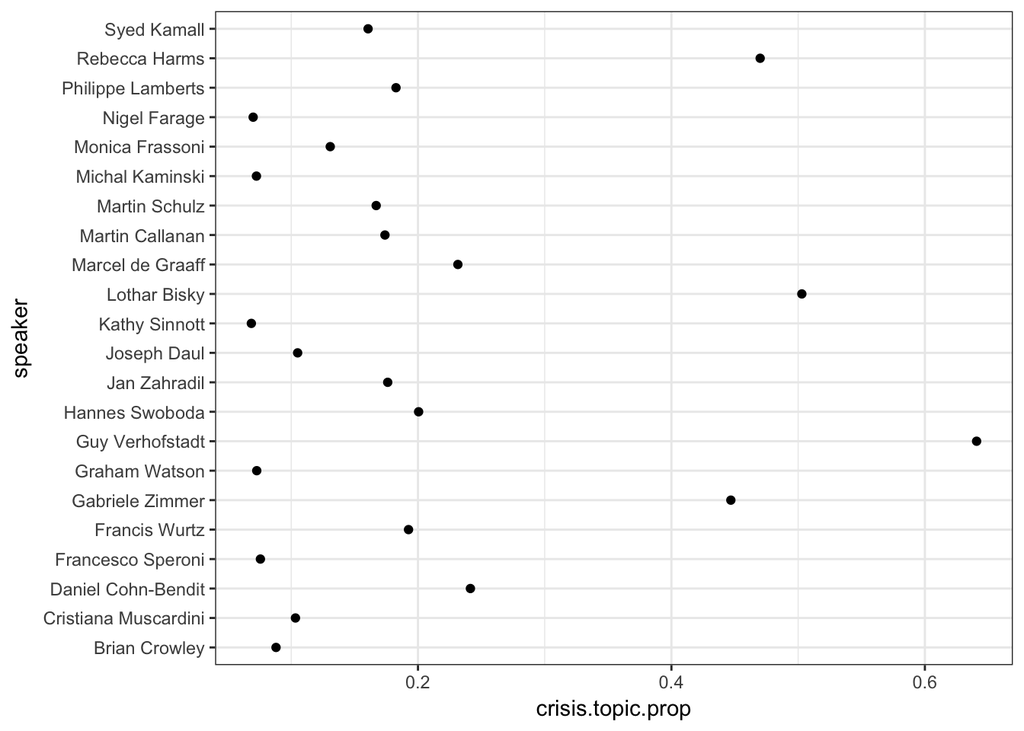

```r
#change the document names to the speaker names
docnames(speeches.dfm) <- docvars(speeches.dfm, "speaker")

topic.plot <- ggplot(docvars(speeches.dfm), aes(x= crisis.topic.prop, y = speaker))
topic.plot <- topic.plot + geom_point() + theme_bw()
print(topic.plot)
```

Do you think this is a good way of summarizing a topic model? Why yes or why no?

Take a look at topic proportions for each speaker

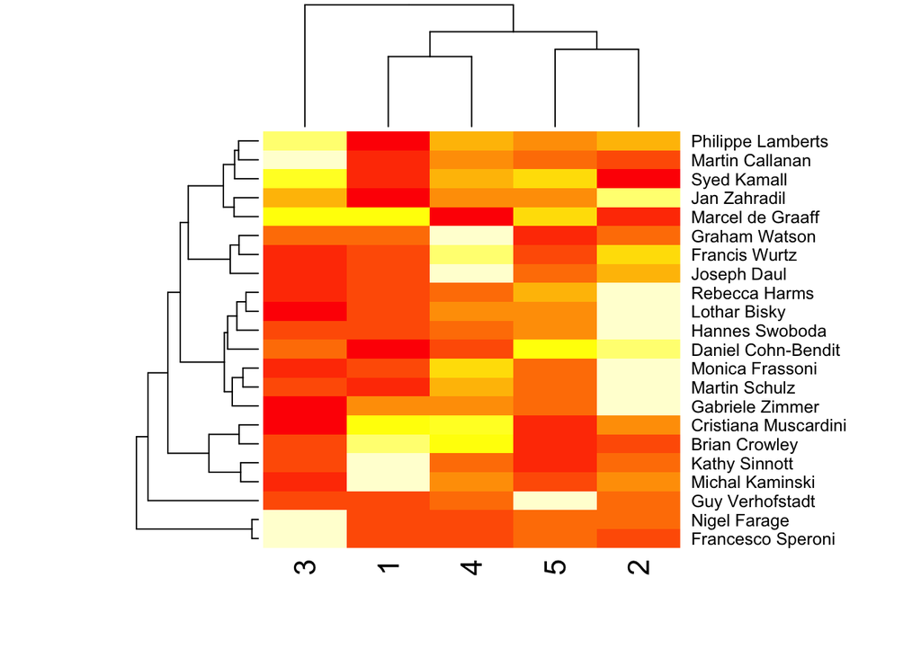

```r
#append the topic proportions

topic.proportions <- posterior(speeches.lda.5)$topics
rownames(topic.proportions) <- rownames(speeches.dfm)

heatmap(as.matrix(topic.proportions[]))
```